# Hypothesis Tests on the Correlation Coefficient

Reece Fannon

2024-10-11

# 1 The Relationship Between Slope $\beta_1$ and the Correlation Coefficient $\rho$

When we consider the equation $Y = \beta_0 + \beta_1X$, the actual part that shows a relationship between $X$ and $Y$ is $\beta_1$. If we tested to see $\beta_0 = 0$, and we found it didn’t, then $Y = \beta_0$ would just be a horizontal line, for every level of $X$. But even if $\beta_0 = 0$, $Y = \beta_1X$ changes as $X$ varies. It is a sloped line, and gives a meaningful relationship between $X$ and $Y$. The direction of the relationship is positive ($\beta_1 > 0$) or negative ($\beta_1 < 0$) and furthermore the magnitude of the slope/relationship is given by $|\beta_1|$. If $|\beta_1| < 1$, then $Y$ changes slower than $X$ does, and if $|\beta_1| > 1$, then $Y$ changes faster than $X$ does. (At this point, you should recall the comment I gave you on homework 1 (I think it was homework 1)).

We sometimes use the correlation coefficient to tell us the direction and strength of the linear relationship. Let $\rho_{XY}$ be the true population correlation coefficient between $X$ and $Y$. So if we had data on every observation in the population, then $\rho_{XY}$ is what we would calculate. Recall that

$$\rho_{XY} = \frac{\sigma^2_{XY}}{\sqrt{\sigma^2_X \sigma^2_Y}} = \frac{Cov(X,Y)}{\sqrt{V(X)V(Y)}}$$

Now you might be tempted to say “X is a known constant, so we would have $\frac{0}{0}$!?!?!??!?!” In the population, it is fine for $X$ to be a random variable. When we collect a sample, we effectively treat $X$ like a nuisance variable and thus assume it to be known for simplicity, since we are not interested in $X$, but only in $Y$. Regardless, since we do not have data on the whole population and thus do not know these values, we use the sample statistic estimators:

$$\hat{\rho_{XY}} = r_{XY} = \frac{S_{XY}}{\sqrt{S_{XX}S_{YY}}}$$

But we can do a little algebraic manipulation to obtain

$$\hat{\rho_{XY}} = r_{XY} = \frac{S_{XY}}{S_{XX}}\sqrt{\frac{S_{XX}}{S_{YY}}} = b_1\sqrt{\frac{S_{XX}}{S_{YY}}}$$

Thus, the sample correlation coefficient is just a constant multiple of the estimated slope $b_1$. Additionally, since $\sqrt{\frac{S_{XX}}{S_{YY}}} > 0$ because $S_{XX} > 0$ and $S_{YY} > 0$, then we have that the $sign(r_{XY}) = sign(b_1)$, meaning that $r_{XY} > 0 \iff b_1 > 0$ (a positive relationship) and $r_{XY} < 0 \iff b_1 < 0$ (a negative relationship). Furthermore, $r_{XY} = 0 \iff b_1 = 0$! So you could alterntaviely test the hypothesis $H_0:\rho_{XY} = 0\ vs\ H_a:\rho_{XY} \neq 0$. If we reject the null hypothesis and conclude $r_{XY} \neq 0$, then we know $b_1 \neq 0$ and thus we have a linear relationship between $X$ and $Y$!

# 2 How can We Test it?

Suppose we want to test $H_0:\rho_{XY} = 0\ vs\ H_a:\rho_{XY} \neq 0$, to see if a linear relationship exists. We need to find the sampling distribution of estimator $r_{XY}$ so that we can do inference on the population parameter $\rho_{XY}$. Since we know $r_{XY} = b_1\sqrt{\frac{S_{XX}}{S_{YY}}}$ and we know the distribution of $b_1$, then let’s work with that:

$$r_{XY} = b_1\sqrt{\frac{S_{XX}}{S_{YY}}},b_1 \sim N(\beta_1, \frac{\sigma^2}{S_{XX}})$$

$$S_{YY} = \sum_{i=1}^{n}(Y_i - \bar{Y})^2 = (n-1)\frac{1}{n-1}\sum_{i=1}^{n}(Y_i - \bar{Y})^2 = (n-1)S^2_Y = \sigma^2\frac{(n-1)S^2_Y}{\sigma^2}
\sim \sigma^2\chi^2_{n-1}$$

$$r_{XY} = b_1\sqrt{\frac{S_{XX}}{S_{YY}}} \sim N(\beta_1, \frac{\sigma^2}{S_{XX}})\sqrt{\frac{S_{XX}}{\sigma^2\chi^2_{n-1}}} = \sqrt{\frac{S_{XX}}{\sigma^2}}N(\beta_1, \frac{\sigma^2}{S_{XX}})\sqrt{\frac{1}{\chi^2_{n-1}}} = N(\beta_1, 1)\sqrt{\frac{1}{\chi^2_{n-1}}} = \frac{N(\beta_1, 1)}{\sqrt{\chi^2_{n-1}}}$$

This form should remind you of the formula for the $T$ distribution. But we need standard normal in the numerator and we need an $n-1$ in the denominator. We can attempt to simplify this as is to obtain the **true** sampling distribution of $r_{XY}$, regardless of the value of $\beta_1$. But we can do a neat trick here. Recall under the null hypothesis, **IF** $H_0: \rho_{XY} = 0$ is true, then $H_0: \rho_{XY} = 0 \iff \beta_1 = 0$. So we can set $\beta_1 = 0$ in the numerator under the null hypothesis to obtain standard normal. The rest is just simple algebraic manipulation:

$$r_{XY} \sim \frac{N(\beta_1, 1)}{\sqrt{\chi^2_{n-1}}},H_0: \frac{N(0, 1)}{\sqrt{\chi^2_{n-1}}} = \frac{Z}{\sqrt{n-1}\sqrt{\chi^2_{n-1}/n-1}} = \frac{1}{\sqrt{n-1}}\frac{Z}{\sqrt{\chi^2_{n-1}/n-1}} = \frac{T_{n-1}}{\sqrt{n-1}}$$

$$\sqrt{n-1}r_{XY} \sim T_{n-1}$$

Note that this is **NOT** the true sampling distribution of $r_{XY}$, because not only is this **only** valid under the null hypothesis $H_0: \rho_{XY} = 0 \iff \beta_1 = 0$, but also recall

$$r_{XY} \in [-1,1] \Rightarrow \sqrt{n-1}r_{XY} \in [-\sqrt{n-1}, \sqrt{n-1}]$$

which is a bounded range but $T_{n-1}$ is unbounded. Regardless, $\sqrt{n-1}r_{XY} = 0 \iff r_{XY} = 0$ and it is a good approximation for the special case $H_0: \rho_{XY} = 0\ vs\ H_a: \rho_{XY} \neq 0$.

# 3 Simulation Study

Let’s do some simulation. We generate $10,000$ samples of size $100$ from some population, and we will calculate the correlation coefficient $r_{XY}$ for each sample, thus generating a sampling distribution of $r_{XY}$. Let’s first assume that their is little to no clear linear relationship between $X$ and $Y$ (aka, we expect $\rho_{XY} = 0 \Rightarrow r_{XY}$ should be around $0$). Since the sample size is $100$, then the degrees of freedom is $n-1 = 99$.

Figure 3.1: Sampling Distribution of $r_{XY}$ with High Variance

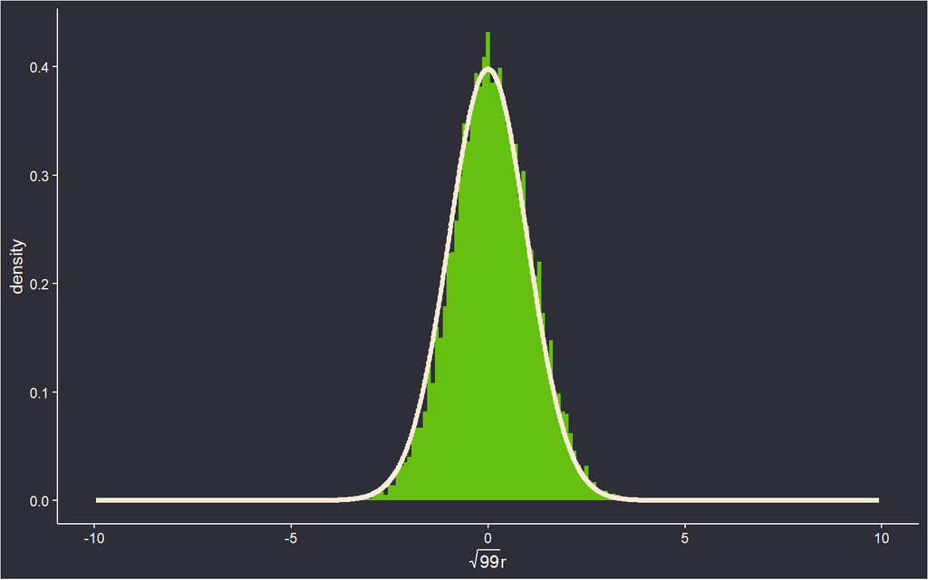

```r
cors = numeric(10000)
for (i in 1:10000)
{
  X = rnorm(100, 50, 10)
  Y = X + rnorm(100, 0, 1000) # correlation roughly zero
  cors[i] = cor(X, Y)
}

ggplot() +
  geom_histogram(aes(x = cors*sqrt(99), y = ..density..), fill = "chartreuse", alpha = .7, binwidth = .1) +
  geom_line(aes(x = seq(-sqrt(99),sqrt(99),.01), y = dt(seq(-sqrt(99),sqrt(99),.01), 99)),lwd=1.5,col="antiquewhite") +
  labs(x = expression(sqrt(99)*r)) +
  theme_classic() +
  theme(plot.background = element_rect(fill = "#2d2e37"),
        panel.background = element_rect(fill = "#2d2e37"),
        axis.title = element_text(colour = "white"),
        axis.ticks = element_line(colour = "white"),
        axis.text = element_text(colour = "white"),
        axis.line = element_line(colour = "white"))
```

We see that the sampling distribution of $r_{XY}$ (though technically it is $\sqrt{99}r_{XY}$) is pretty much exactly a $T_{99}$ distribution. In this case, we would fail to reject the null hypothesis because we are confident $\rho_{XY} = 0$ and thus there is no linear relationship between $X$ and $Y$. Now let’s see what happens when we increase the correlation:

Figure 3.2: Sampling Distribution of $r_{XY}$ with Low Variance, Positive Realtionship

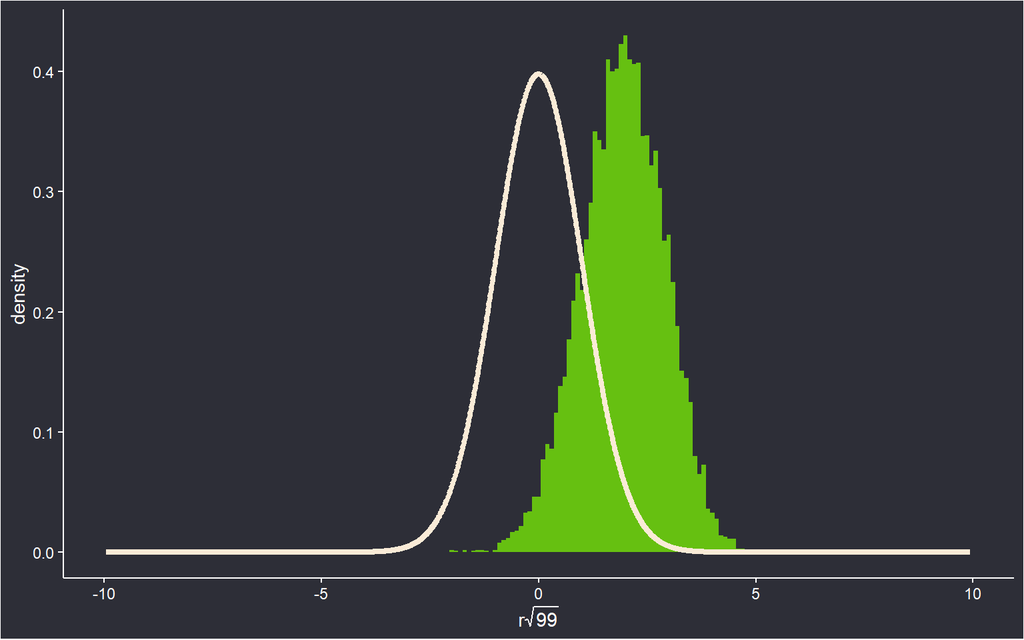

```r
cors = numeric(10000)
for (i in 1:10000)
{
  X = rnorm(100, 50, 10)
  Y = X + rnorm(100, 0, 50) # correlation roughly zero
  cors[i] = cor(X, Y)
}

ggplot() +
  geom_histogram(aes(x = cors*sqrt(99), y = ..density..), fill = "chartreuse", alpha = .7, binwidth = .1) +
  geom_line(aes(x = seq(-sqrt(99),sqrt(99),.01), y = dt(seq(-sqrt(99),sqrt(99),.01), 99)),lwd=1.5,col="antiquewhite") +
  labs(x = expression(r*sqrt(99))) +
  theme_classic() +
  theme(plot.background = element_rect(fill = "#2d2e37"),
        panel.background = element_rect(fill = "#2d2e37"),
        axis.title = element_text(colour = "white"),
        axis.ticks = element_line(colour = "white"),
        axis.text = element_text(colour = "white"),
        axis.line = element_line(colour = "white"))
```

Now the distribution of $r_{XY}$ is skewed to the left. The mean of distribution is to the right of the null hypothesized $T_{99}$ distribution. Since the sampling distribution does not match the hypothesized distribution, then we would reject the null hypothesis because we are confident that a positive relationship exists between $X$ and $Y$. Similarly, let’s see what happens when the correlation is negative ($Y$ decreases as $X$ increases):

Figure 3.3: Sampling Distribution of $r_{XY}$ with Low Variance, Negative Relationship

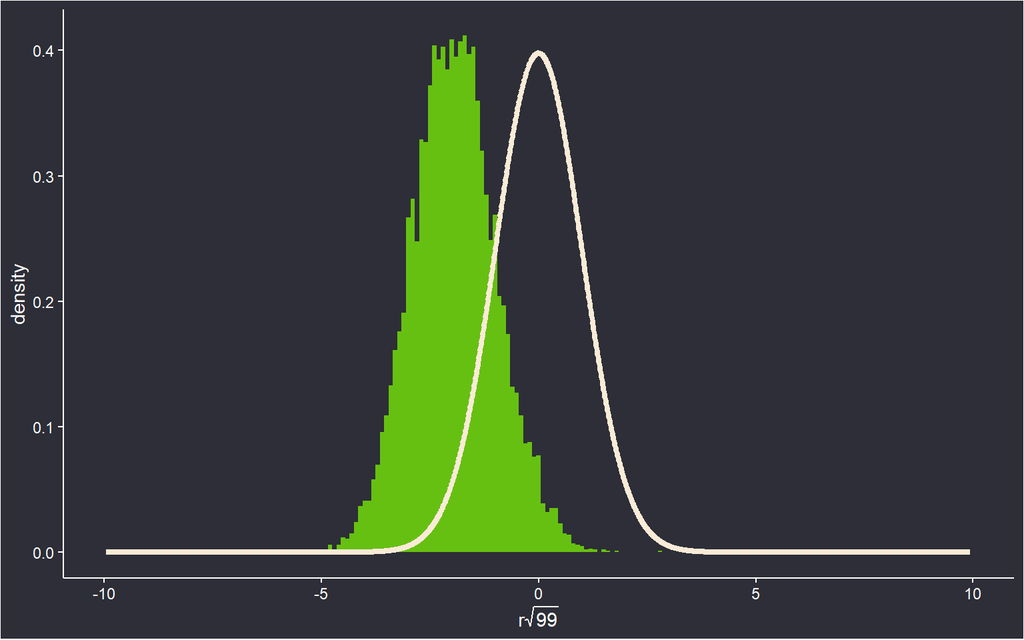

```r
cors = numeric(10000)
for (i in 1:10000)
{
  X = rnorm(100, 50, 10)
  Y = -X + rnorm(100, 0, 50) # correlation roughly zero
  cors[i] = cor(X, Y)
}

ggplot() +
  geom_histogram(aes(x = cors*sqrt(99), y = ..density..), fill = "chartreuse", alpha = .7, binwidth = .1) +
  geom_line(aes(x = seq(-sqrt(99),sqrt(99),.01), y = dt(seq(-sqrt(99),sqrt(99),.01), 99)),lwd=1.5,col="antiquewhite") +
  labs(x = expression(r*sqrt(99))) +
  theme_classic() +
  theme(plot.background = element_rect(fill = "#2d2e37"),
        panel.background = element_rect(fill = "#2d2e37"),
        axis.title = element_text(colour = "white"),
        axis.ticks = element_line(colour = "white"),
        axis.text = element_text(colour = "white"),
        axis.line = element_line(colour = "white"))
```

The distribution of $r_{XY}$ is skewed to the right. The mean of distribution is to the left of the null hypothesized $T_{99}$ distribution. Since the sampling distribution does not match the hypothesized distribution, then we would reject the null hypothesis because we are confident that a negative relationship exists between $X$ and $Y$.

Now let’s see that the hypothesis tests for slope $b_1$ and correlation coefficient $r_{XY}$ are approximately the same. We first test a strong and obvious linear relationship.

Figure 3.4: A Scatter Plot with a Strong Linear Relationship

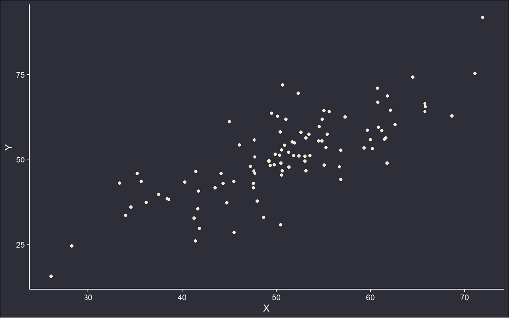

```r
X = rnorm(100, 50, 10)
Y = X + rnorm(100, 0, 7)
ggplot() +
  geom_point(aes(x = X, y = Y), col = "antiquewhite") +
  theme_classic() +
  theme(plot.background = element_rect(fill = "#2d2e37"),
        panel.background = element_rect(fill = "#2d2e37"),
        axis.title = element_text(colour = "white"),
        axis.ticks = element_line(colour = "white"),
        axis.text = element_text(colour = "white"),
        axis.line = element_line(colour = "white"))
```

```r
r = cor(X, Y)

summary(lm(Y~X))
```

```
##
## Call:
## lm(formula = Y ~ X)
##
## Residuals:
##      Min       1Q   Median       3Q      Max
## -19.7878  -4.2335  -0.2375   3.5430  20.9953
##
## Coefficients:
##             Estimate Std. Error t value Pr(>|t|)
## (Intercept)  -3.0128     4.3605  -0.691    0.491
## X             1.0618     0.0843  12.596   <2e-16 ***
## ---
## Signif. codes:  0 '***' 0.001 '**' 0.01 '*' 0.05 '.' 0.1 ' ' 1
##
## Residual standard error: 7.549 on 98 degrees of freedom
## Multiple R-squared:  0.6182, Adjusted R-squared:  0.6143
## F-statistic: 158.7 on 1 and 98 DF,  p-value: < 2.2e-16
```

```r
2*pt(sqrt(99)*r, 99, lower.tail = FALSE)
```

```
## [1] 5.735429e-12
```

The $p_{value}$ associated with $b_1$ for predictor $X$ is effectively $0$, as is the two-tailed $p_{value}$ for the correlation coefficient using $T_{99}$ (though again, we technically must use $\sqrt{n-1}r_{XY}$, so is the $p_{value}$ associated with $\sqrt{99}r_{XY}$). In either case, we reject the null hypothesis and conclude that a linear association exists between $X$ and $Y$.

Now let’s see what happens to the $p_{value}$ when the linear relationship is not so strong and obvious.

Figure 3.5: A Scatter Plot with a Weak Linear Relationship

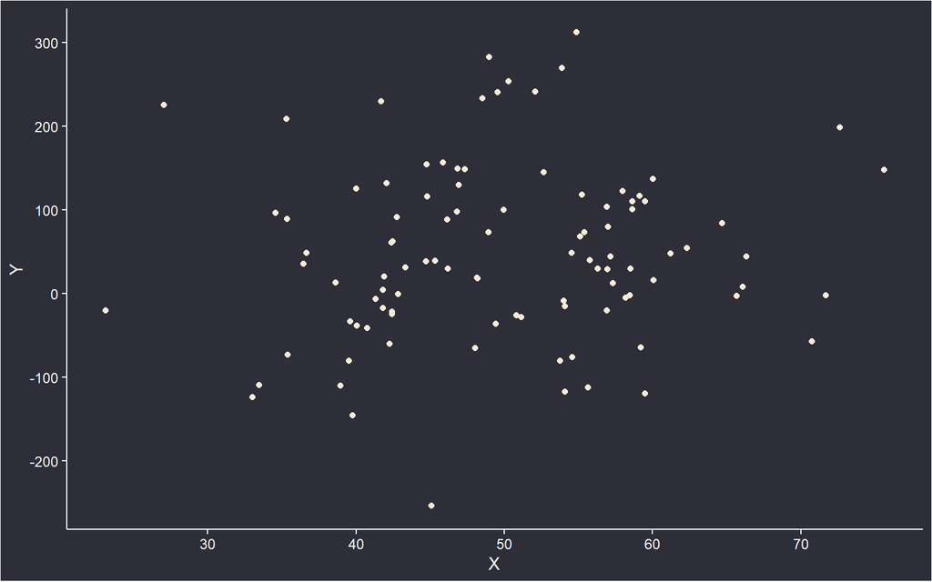

```r
X = rnorm(100, 50, 10)
Y = X + rnorm(100, 0, 100)
ggplot() +
  geom_point(aes(x = X, y = Y), col = "antiquewhite") +
  theme_classic() +
  theme(plot.background = element_rect(fill = "#2d2e37"),
        panel.background = element_rect(fill = "#2d2e37"),
        axis.title = element_text(colour = "white"),
        axis.ticks = element_line(colour = "white"),
        axis.text = element_text(colour = "white"),
        axis.line = element_line(colour = "white"))
```

```r
r = cor(X, Y)

summary(lm(Y~X))
```

```
##
## Call:
## lm(formula = Y ~ X)
##
## Residuals:
##     Min      1Q  Median      3Q     Max
## -297.17  -67.12  -11.26   60.62  259.38
##
## Coefficients:
##             Estimate Std. Error t value Pr(>|t|)
## (Intercept)   -3.088     53.236  -0.058    0.954
## X              1.025      1.048   0.978    0.330
##
## Residual standard error: 104.5 on 98 degrees of freedom
## Multiple R-squared:  0.009666,   Adjusted R-squared:  -0.0004392
## F-statistic: 0.9565 on 1 and 98 DF,  p-value: 0.3305
```

```r
2*pt(sqrt(99)*r, 99, lower.tail = FALSE)
```

```
## [1] 0.3303383
```

Now the $p_{value}$s are much higher, and they are approximately equal. In either case, we fail to reject the null hypothesis and conclude that there is no linear relationship between $X$ and $Y$.

We can similarly test when the association is **NOT** linear

Figure 3.6: A Scatter Plot with a Non-linear Relationship

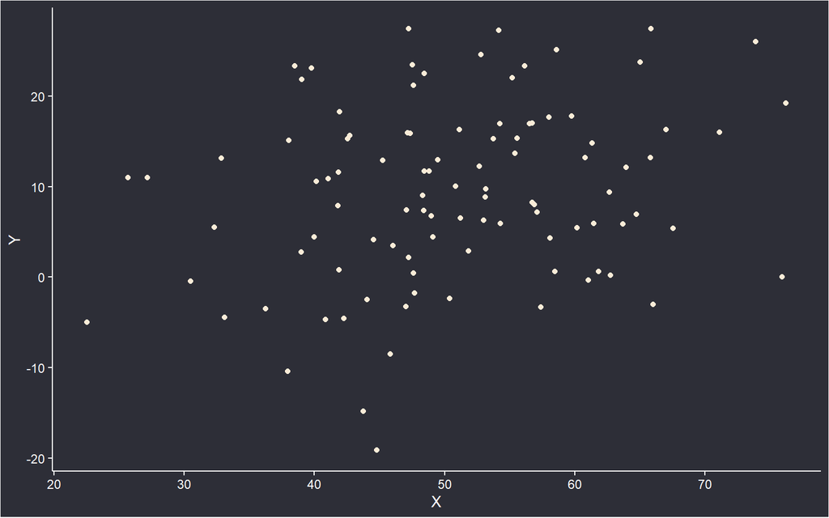

```r
X = rnorm(100, 50, 10)
Y = sqrt(X) + rnorm(100, 0, 10)
ggplot() +
  geom_point(aes(x = X, y = Y), col = "antiquewhite") +
  theme_classic() +
  theme(plot.background = element_rect(fill = "#2d2e37"),
        panel.background = element_rect(fill = "#2d2e37"),
        axis.title = element_text(colour = "white"),
        axis.ticks = element_line(colour = "white"),
        axis.text = element_text(colour = "white"),
        axis.line = element_line(colour = "white"))
```

```r
r = cor(X, Y)

summary(lm(Y~X))
```

```
##
## Call:
## lm(formula = Y ~ X)
##
## Residuals:
##      Min       1Q   Median       3Q      Max
## -27.2046  -6.4359   0.1245   6.8407  18.8432
##
## Coefficients:
##             Estimate Std. Error t value Pr(>|t|)
## (Intercept) -1.28841    4.59201  -0.281   0.7796
## X            0.20904    0.08844   2.364   0.0201 *
## ---
## Signif. codes:  0 '***' 0.001 '**' 0.01 '*' 0.05 '.' 0.1 ' ' 1
##
## Residual standard error: 9.527 on 98 degrees of freedom
## Multiple R-squared:  0.05393,    Adjusted R-squared:  0.04428
## F-statistic: 5.586 on 1 and 98 DF,  p-value: 0.02007
```

```r
2*pt(sqrt(99)*r, 99, lower.tail = FALSE)
```

```
## [1] 0.02292717
```

Again, the p-values are close to each other, and are significant, but not *significantly* significant.

# 4 Why would we Want to Test Correlation Coefficient?

If we conclude that $\beta_1 \neq 0$, this tells us that there is a linear relationship and the point estimate or confidence interval will tell us the effect size that $X$ has on $Y$. But recall effect size is not a unitless metric and it depends on the scale and units of the problem. Just because $\beta_1$ is large, this does not mean that the linear relationship is strong, nor that it is any more significant than some other $\beta_2 \neq 0, s.t.\beta_1 >> \beta_2$ associated with some other predictor $X_2$.

Alternatively, if we conclude that $\rho_{XY} \neq 0$, this not only tells us that a linear relationship exists, but also the point estimate and confidence interval tell us how strong it is. It is unitless and always between $-1$ and $1$, so we can definitely say that if we have two predictors $X_1$ and $X_2$ and we find $\rho_{X_1Y} > \rho_{X_2Y}$, then we can conclude that $X_1$ has a better linear relationship with $Y$ than $X_2$. So $X_1$ is a better predictor. However, $\rho_{XY}$ does not tell us effect size or the actual coefficient, so we lose this information. Pros and cons to each, and it depends on what you want to look for.

Note since $r_{XY} = b_1\sqrt{\frac{S_{XX}}{S_{YY}}}$, then $b_1 = r_{XY}\sqrt{\frac{S_{YY}}{S_{XX}}}$, so no matter which one you compute for your hypothesis tests, we can always calculate the other.